# 第四讲课堂笔记

# 另一种方法

```r
lfs %>%
   ggplot(aes(HOURPAY)) +
  geom_histogram() +
  labs( title = "Distribution of hourly wage",
        subtitle = "Sample of people earning less than £70 per hour",
        x = "Hourly wage (£)",
        y = "Count",
        caption = "Source: Quarterly Labour Force Survey - January-March 2025") +
  theme_minimal() +
  coord_cartesian(xlim = c(0,70))
```

# 另一种方法

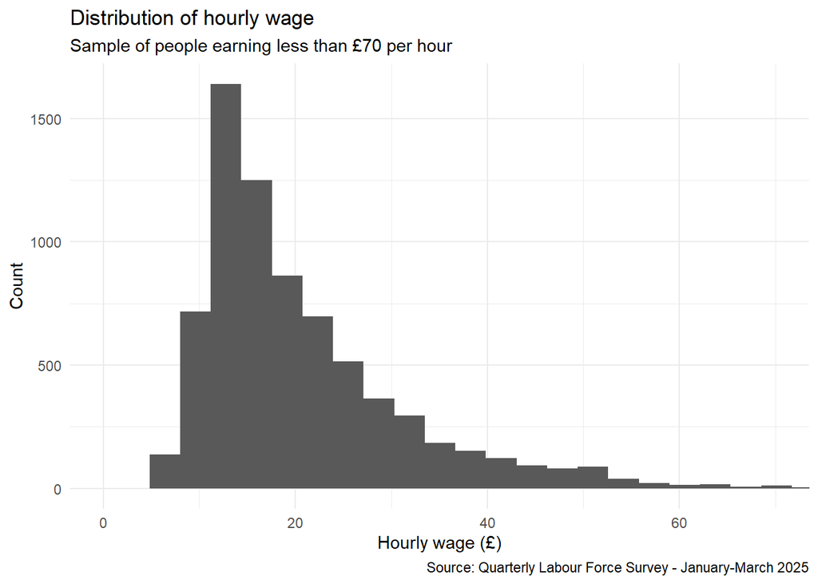

# 线性刻度与对数刻度

- 我们的横轴使用线性刻度。
- 沿着坐标轴移动时，数值按固定的幅度增加。
- 当最大值远大于最小值时，这种刻度未必合适。
- 在对数刻度上，数值沿轴的增长幅度会越来越大。
- 1到10的距离等于10到100的距离，也等于100到1000的距离。
- 这样可以在较小的图形范围内展示跨度很大的数值。
- 注意：数据中存在零值时，对数变换不能直接应用，因为0的对数不存在。

# 采用对数刻度的直方图

```r
lfs %>%
   ggplot(aes(HOURPAY)) +
  geom_histogram() +
  labs( title = "Distribution of hourly wage",
        subtitle = "Logarithmic scale",
        x = "Hourly wage (£)",
        y = "Count",
        caption = "Source: Quarterly Labour Force Survey - January-March 2025") +
  theme_minimal() +
  scale_x_log10()
```

# 采用对数刻度的直方图

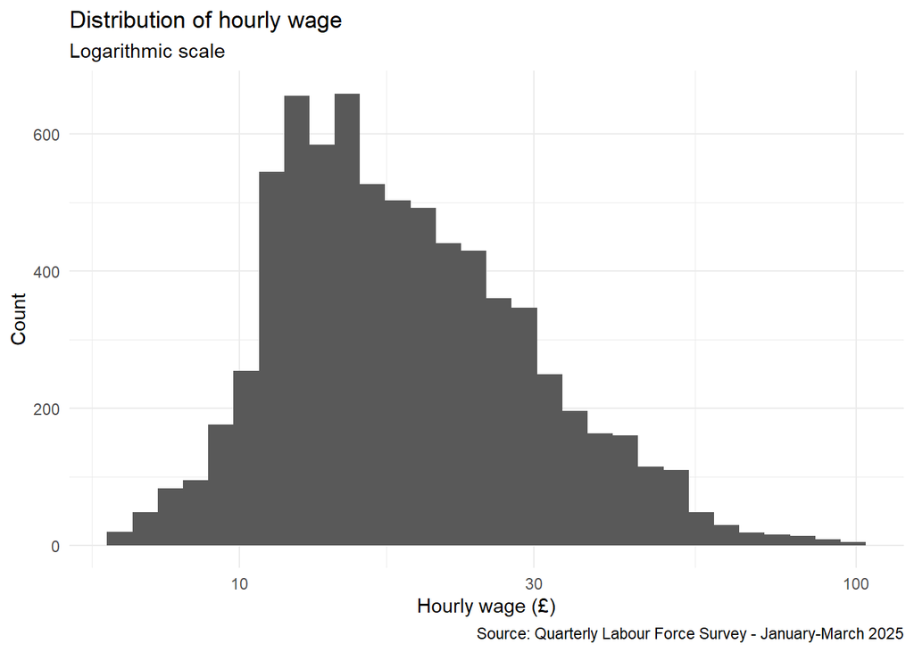

# 密度图

- 密度图与直方图密切相关，能告诉我们许多相似的信息。
- 它不将数据分到不同区间，而是使用核平滑方法来减少噪声。
- 这有助于观察潜在的数据分布。
- 也可以避免直方图由于区间数量选择不当而引发的一些问题。
- 密度图的绘制方式与直方图非常相似。

# 采用对数刻度的密度图

```r
lfs %>%
   ggplot(aes(HOURPAY)) +
  geom_density() +
  labs( title = "Distribution of hourly wage",
        subtitle = "Logarithmic scale",
        x = "Hourly wage (£)",
        y = "Density",
        caption = "Source: Quarterly Labour Force Survey - January-March 2025") +
  theme_minimal() +
  scale_x_log10()
```

# 采用对数刻度的密度图

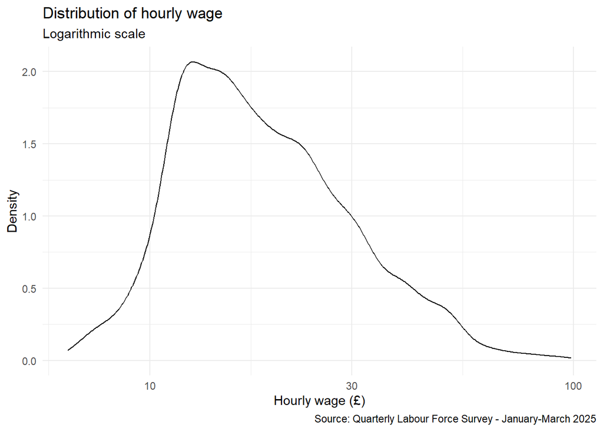

# 在图中添加地毯图（rug）

- 在图中添加rug（地毯图），会在图形底部添加一排短线。
- 其中的竖线表示每一个数据点所在的位置。
- 它不占用太多额外空间，却能够提供分布的附加信息。
- 通过添加geom_rug图层，就能得到这种图形。

# 采用对数刻度的密度图

```r
lfs %>%
   ggplot(aes(HOURPAY)) +
  geom_density() +
  labs( title = "Distribution of hourly wage",
        subtitle = "Logarithmic scale",
        x = "Hourly wage (£)",
        y = "Density",
        caption = "Source: Quarterly Labour Force Survey - January-March 2025") +
  theme_minimal() +
  scale_x_log10() +
  geom_rug()
```

# 采用对数刻度的密度图

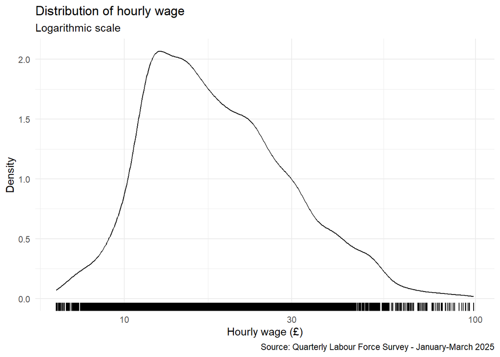

# 我们应该关注什么？

- 直方图和密度图呈现的信息非常相似。
- 均值附近存在较为集中的一组观测。
- 这个分布只有一个峰值。
- 有时也可能出现多个峰值，这时我们需要研究其原因。
- 也要留意任何不合理的异常现象。
- 分布高度右偏，也就是说，一部分人的小时工资非常高。

# 进一步完善密度图

- 如果愿意，可以为密度曲线下方的区域填色。
- 假设我们想把它填成蓝色。

# 采用对数刻度的密度图

```r
lfs %>%
   ggplot(aes(HOURPAY)) +
  geom_density(fill="blue") +
  labs( title = "Distribution of hourly wage",
        subtitle = "Logarithmic scale",
        x = "Hourly wage (£)",
        y = "Density",
        caption = "Source: Quarterly Labour Force Survey - January-March 2025") +
  theme_minimal() +
  scale_x_log10() +
  geom_rug()
```

# 采用对数刻度的密度图

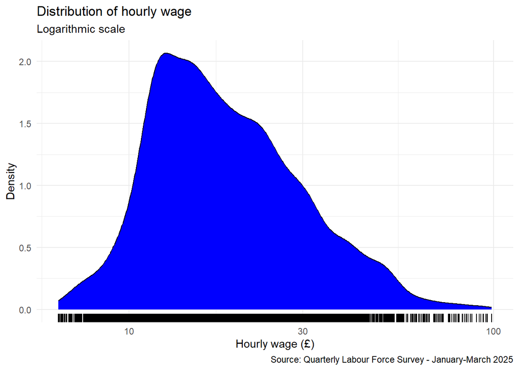

# 添加另一个变量

- 仅仅填上颜色虽然美观，却不能提供更多信息。
- 可以绘制不止一条密度曲线。
- 然后根据观测所属的组别分别填色。
- 在这里，可以使用SEX变量进行分组。
- 需要将这一信息加入美学映射中。
- 既可以在ggplot调用中设置，也可以在geom_density调用中设置。

# 采用对数刻度的密度图

```r
lfs %>%
   ggplot(aes(HOURPAY)) +
  geom_density(aes(fill=SEX)) +
  labs( title = "Distribution of hourly wage by sex",
        subtitle = "Logarithmic scale",
        x = "Hourly wage (£)",
        y = "Density",
        caption = "Source: Quarterly Labour Force Survey - January-March 2025") +
  theme_minimal() +
  scale_x_log10() +
  geom_rug()
```

# 采用对数刻度的密度图

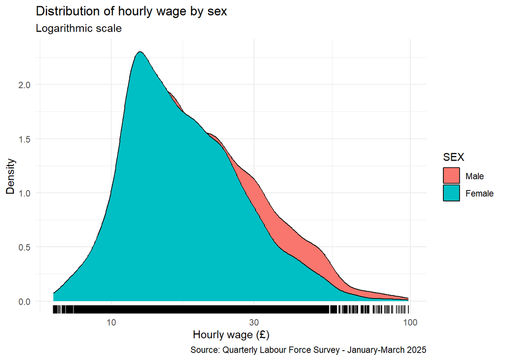

# 改进图表

- 这幅图已经很有信息量，但多条曲线彼此重叠。
- 降低填充区域的不透明度，可以缓解这一问题。
- 通过设置alpha参数即可实现。

# 采用对数刻度的密度图

```r
lfs %>%
   ggplot(aes(HOURPAY)) +
  geom_density(aes(fill=SEX), alpha=0.2) +
  labs( title = "Distribution of hourly wage by sex",
        subtitle = "Logarithmic scale",
        x = "Hourly wage (£)",
        y = "Density",
        caption = "Source: Quarterly Labour Force Survey - January-March 2025") +
  theme_minimal() +
  scale_x_log10() +
  geom_rug()
```

# 采用对数刻度的密度图

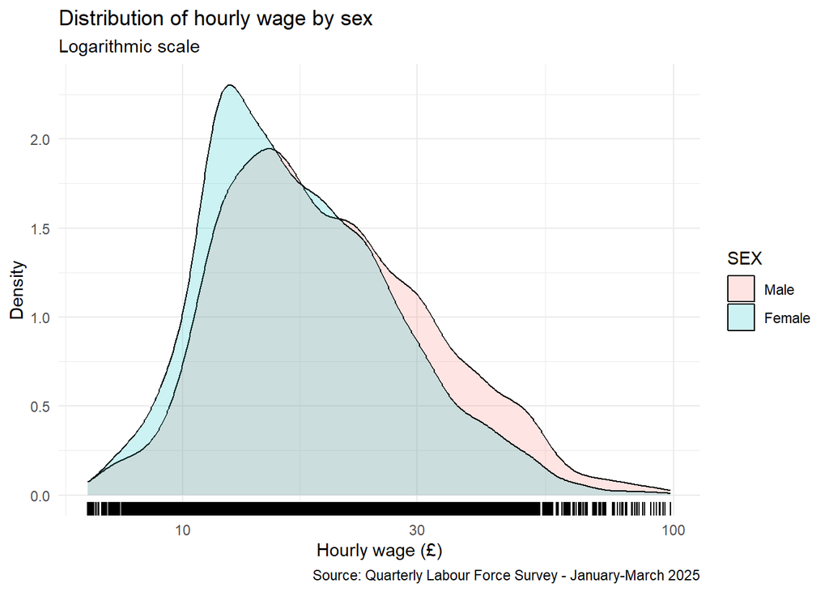

# 图例

- 图例帮助读者理解图中展示的内容。
- 如有需要，可以自行定制图例。
- 一幅图中的分组数量应有所限制。
- 通常最多只有约8种颜色能被清楚地区分。
- 颜色选择很重要，ggplot2会尝试默认使用合适的颜色。
- 还有许多扩展包提供不同的调色方案，例如viridis或ggthemes。
- 也要考虑色觉辨识存在困难的人群（讲义称约占英国人口的4.5%，其中多数为男性）。

# 图例

- 当前图例直接使用变量名SEX作为标题。
- 虽然这个名称至少有明确含义，但不应该全部大写。
- 在这个例子中，图表标题和类别标签已足以说明图例内容。
- 因此，可以考虑取消图例标题。
- 图例可以通过labs()函数自定义。
- 也可以使用theme函数。

# 修改图例标签

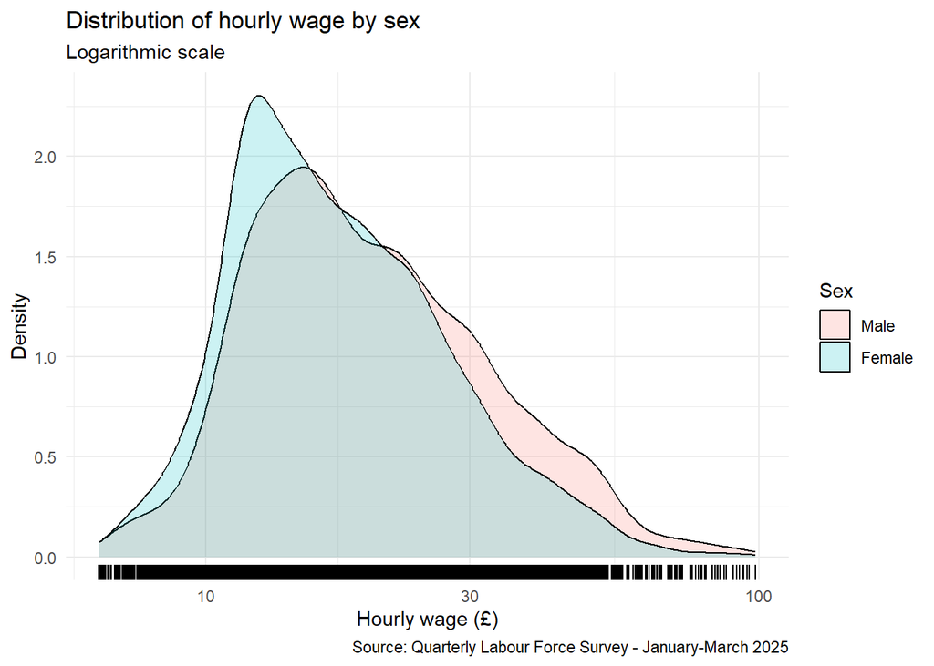

```r
lfs %>%
  ggplot(aes(HOURPAY)) +
  geom_density(aes(fill = SEX), alpha = 0.2) +
  labs( title = "Distribution of hourly wage by sex",
        subtitle = "Logarithmic scale",
        x = "Hourly wage (£)",
        y = "Density",
        fill = "Sex",
        caption = "Source: Quarterly Labour Force Survey - January-March 2025") +
  theme_minimal() +
  scale_x_log10() +
  geom_rug()
```

# 隐藏图例标题（取巧的方法）

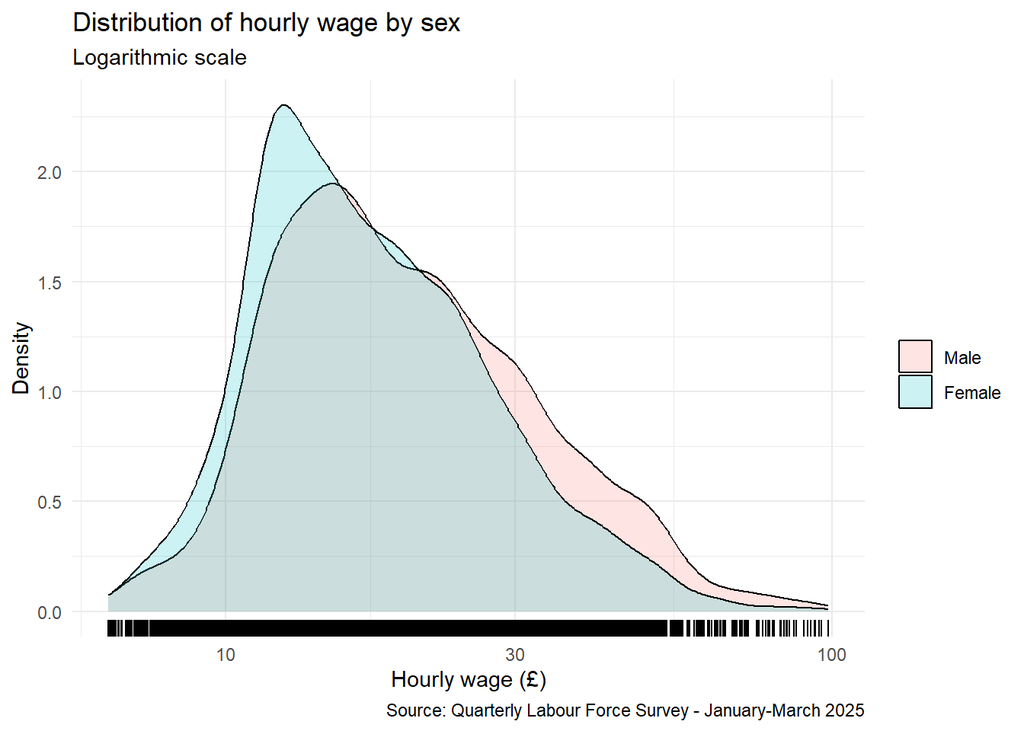

```r
lfs %>%
  ggplot(aes(HOURPAY)) +
  geom_density(aes(fill = SEX), alpha = 0.2) +
  labs( title = "Distribution of hourly wage by sex",
        subtitle = "Logarithmic scale",
        x = "Hourly wage (£)",
        y = "Density",
        fill = "",
        caption = "Source: Quarterly Labour Force Survey - January-March 2025") +
  theme_minimal() +
  scale_x_log10() +
  geom_rug()
```

# 隐藏图例标题（规范的方法）

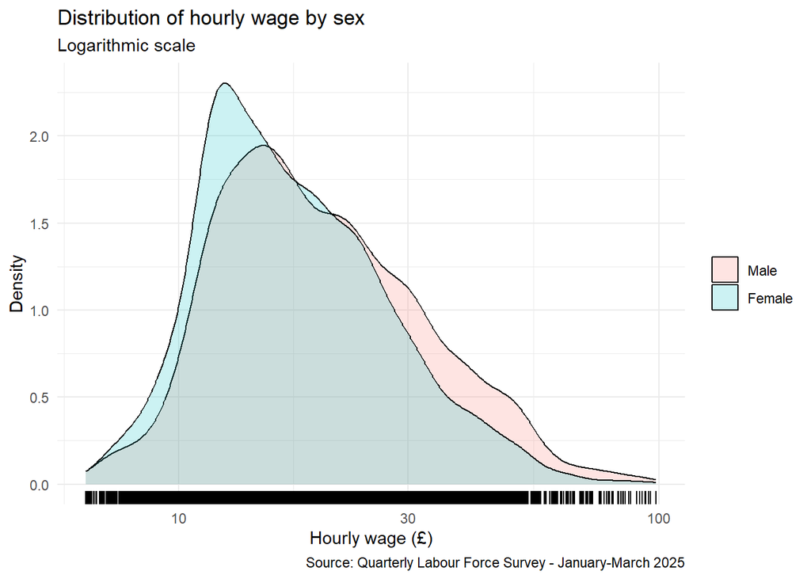

```r
lfs %>%
  ggplot(aes(HOURPAY)) +
  geom_density(aes(fill = SEX), alpha = 0.2) +
  labs( title = "Distribution of hourly wage by sex",
        subtitle = "Logarithmic scale",
        x = "Hourly wage (£)",
        y = "Density",
        caption = "Source: Quarterly Labour Force Survey - January-March 2025") +
  theme_minimal() +
  scale_x_log10() +
  geom_rug() +
  theme(legend.title = element_blank())
```

# 采用对数刻度的密度图

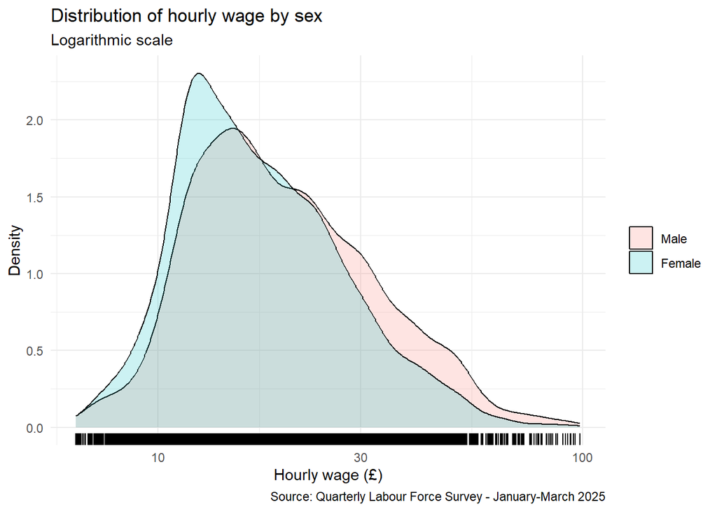

# 修改直方图的填充颜色

- fill视觉属性可用于许多不同类型的图形。
- 我们在直方图上尝试使用它。

# 采用对数刻度的直方图

```r
lfs %>%
  ggplot(aes(HOURPAY)) +
  geom_histogram(aes(fill=SEX)) +
  labs( title = "Distribution of hourly wage by sex",
        subtitle = "Logarithmic scale",
        x = "Hourly wage (£)",
        y = "Count",
        caption = "Source: Quarterly Labour Force Survey - January-March 2025") +
  theme_minimal() +
  scale_x_log10() +
  theme(legend.title = element_blank())
```

# 采用对数刻度的直方图

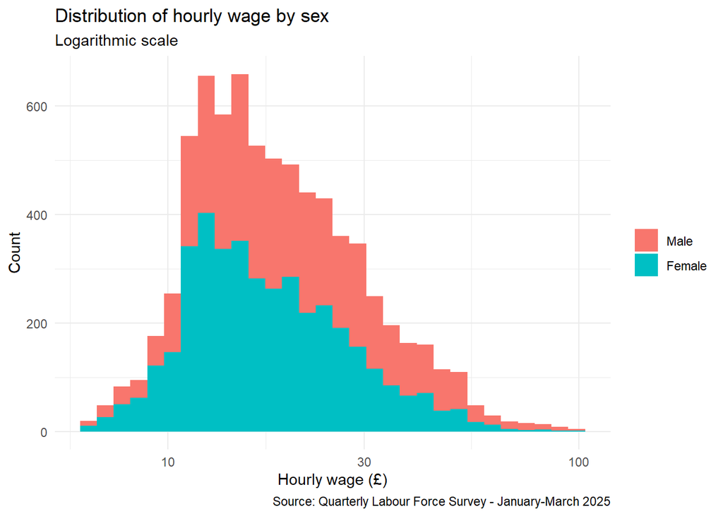

# 总结

- 今天我们认识了R语言中最强大的绘图系统之一。
- 还学习了制作有说服力的数据可视化作品所需的关键基础。
- 下节课将继续拓展今天的内容，探索更多绘图功能。